# 第7回 時系列データ処理（季節性・トレンド除去）

経済データとプログラミングII

第7回

時系列データ処理

トレンドと季節と残差に分ける

経済データとプログラミングII

第7回 — Topic01

時系列データと日付  
インデックス

この線、そのまま読める？

## 第7回の道のり

1

日付を軸にする

実習：実行 アイス店の売上を描く

実習：写経 実質 GDP 原系列の線

演習 7-1 期間の変更

2

ならす

実習：実行 アイス店の移動平均

実習：写経 窓幅 4 と 8

演習 7-2 窓幅の変更

3

分ける

実習：写経 分解と季節調整

演習 7-3 残差の谷

4

外す・確かめる

実習：写経 1 前年比

実習：写経 2 自己相関

演習 7-4 ずらす幅の変更

いまココ — 日付を軸に据えて、線を時間の順に描く

## 前の回の振り返り

前の回のポイント

Q: 前の回は、景気動向指数の 485 か月をどう分けたか

- **13 列**：一致指数を、今月〜12 か月前の先行指数で説明した（1 か月 1 行）
- **正則化**：係数に罰金を掛け、似すぎた列の暴れを抑えた（Ridge・Lasso）
- **分け方**：くじで月を混ぜて、訓練 363 か月・テスト 122 か月
- **罰金の強さ**：標準化して、交差検証で選んだ

前の回まで：時系列も、くじで月を混ぜて分けた。時間の順で区切らない  
今回：その順番そのものを、道具として使う  
この先：過去の値から先を予測するときに、今回の道具を使う

## このトピックで学ぶこと

- **いまの道具**：`read_csv` で読み、`plot` で線は描ける
- **足りないもの**：都道府県の表と違い、売上は順番そのものが意味
- **問い**：日付が文字のままで、線は時間の順に並ぶか
- **このトピック**：日付を時間として渡し、表の軸に据えて描く

この回の「ならす・分ける・前年比」は、  
どれも時間の順にそろっていることが前提

## ◼ 時系列

用語

**時系列**：同じ対象を、時間に沿って並べたデータ

- **断面データ**：一時点の 47 都道府県のような表
- **違い**：時系列は行を並べ替えると意味が壊れる。断面は壊れない
- **インデックス**：表の各行の見出し。日付を置けば**日付インデックス**

だから最初に、日付を表の軸（インデックス）に据える

## アイス店の売上の表

あなたのバイト先のアイス店。3 か月ごとの売上を 2 年分、CSV でもらった

| date（CSV の文字） | 3 か月 | sales（万円） |
| --- | --- | --- |
| 2025/4/1 | 4-6 月 | 26 |
| 2024/10/1 | 10-12 月 | 21 |
| 2024/1/1 | 1-3 月 | 17 |
| 2025/10/1 | 10-12 月 | 25 |
| 2024/7/1 | 7-9 月 | 26 |
| 2025/1/1 | 1-3 月 | 21 |
| 2024/4/1 | 4-6 月 | 22 |
| 2025/7/1 | 7-9 月 | 30 |

日付は**文字**。行の順番も、受け取ったときのまま

## 文字の順と時間の順

[figure not shown]

1 文字ずつ比べるので、10 月の「1」が 4 月の「4」より先

## 並べ方による線の違い

[figure not shown]

時間の順に並べると、毎年 7-9 月に山が来る（26 万円・30 万円）

## ◼ 時系列の作り方

手順

STEP 1`parse_dates=["date"]` で**日付型**として読む

STEP 2`set_index("date").sort_index()` で並べる

STEP 3`.plot()` で折れ線を描く

- **`set_index`**：行の名前を替えるだけ。  
  時間の順に並べるのは `sort_index()`

アイス店の 8 行も、GDP の 129 行も、同じ 3 行で描ける

## アイス店の売上を描くセル

```python
import io
import pandas as pd
csv = """date,sales
2025/4/1,26
2024/10/1,21
2024/1/1,17
2025/10/1,25
2024/7/1,26
2025/1/1,21
2024/4/1,22
2025/7/1,30"""
ice = pd.read_csv(io.StringIO(csv), parse_dates=["date"])
ice = ice.set_index("date").sort_index()
ice["sales"].plot(marker="o")
```

| 行 | 書き方 | 意味 |
| --- | --- | --- |
| 1-2 | 道具を呼ぶ | `io` は、文字で書いた CSV をファイルの代わりに読ませる道具 |
| 3-11 | CSV の中身 | アイス店の売上の表と同じ 8 行（受け取った順のまま） |
| 12-14 | **STEP 1〜3** | 日付型で読む → 軸に据えて並べる → 点つきの折れ線 |

**写経せず、そのまま実行するセル**（ノートの「アイス店」の節）

## 原系列と季節調整済み系列

今度は実質 GDP で、同じ STEP を。題材は 3 か月ごと（四半期）の 2 本

| 系列 | 列名 | 中身 |
| --- | --- | --- |
| **原系列** | `gdp_real_raw` | 集計したまま |
| **季節調整済み系列** | `gdp_real_sa` | 季節の動きを取り除いた もの（作り方はあとで） |

2 本とも 129 点・表の数は十億円。今日使うのは上の**原系列**

## 写経 実質 GDP 原系列の折れ線

```python
!pip install -q japanize-matplotlib
import japanize_matplotlib
BASE = "ここに manaba の URL を貼る"
g = pd.read_csv(BASE + "gdp_real_raw_quarterly.csv",
                parse_dates=["date"])
g = g.set_index("date").sort_index()
tn = g["gdp_real_raw"] / 1000
tn.plot()
```

| 行 | 部品 | 意味 |
| --- | --- | --- |
| 1-2 | 図の日本語 | Colab で日本語を出す 2 行（ノートで一度でよい） |
| 3 | `BASE = "…"` | manaba に載せた URL の**最後の / まで**を貼る |
| 4-5 | **STEP 1** | アイス店と同じ読み方。中身がファイルになっただけ |
| 6 | **STEP 2** | 軸に据えて、時間の順に並べる |
| 7 | 兆円にする | 表の数は十億円。1000 で割ると兆円 |
| 8 | **STEP 3** | 折れ線を描く |

## コードセルの写経と実行

1. **＋ コード**で空のセルを足す  
   （案内の文の下）
2. 前のページの写経、  
   8 行を上から写す
3. **▶** か **Shift + Enter** で実行  
   （Mac は Shift + return）
4. セルの下に、  
   折れ線が出る

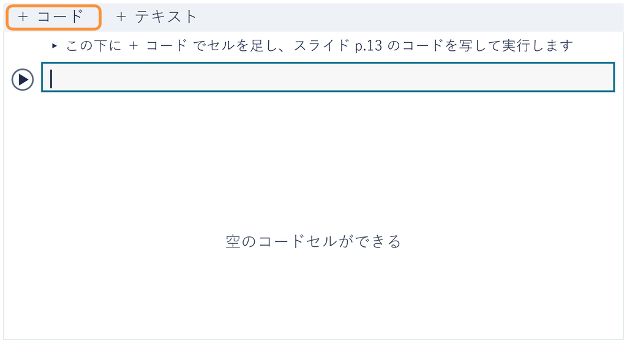

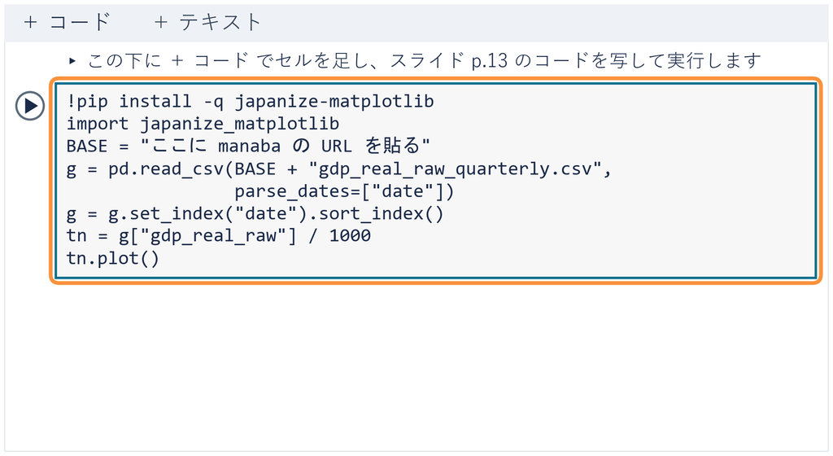

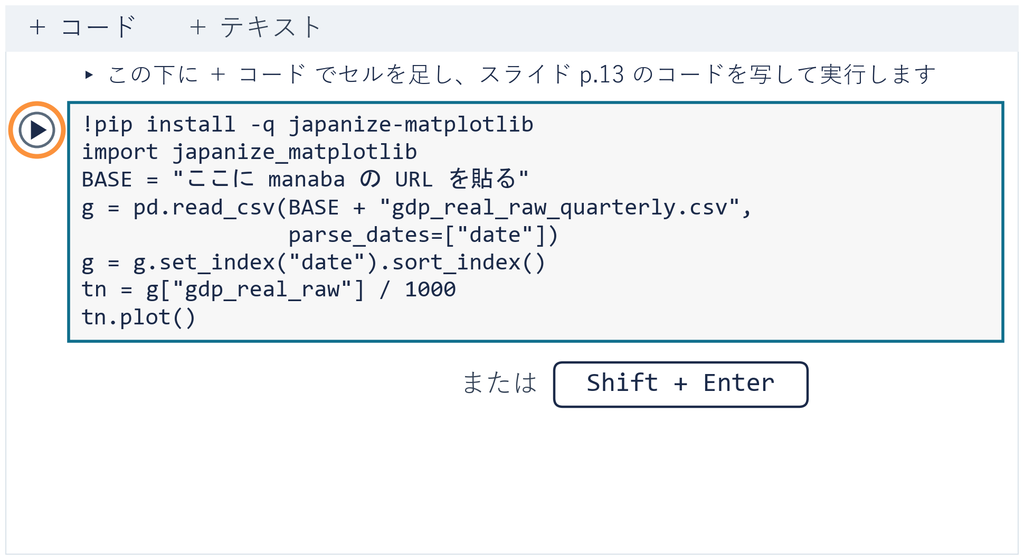

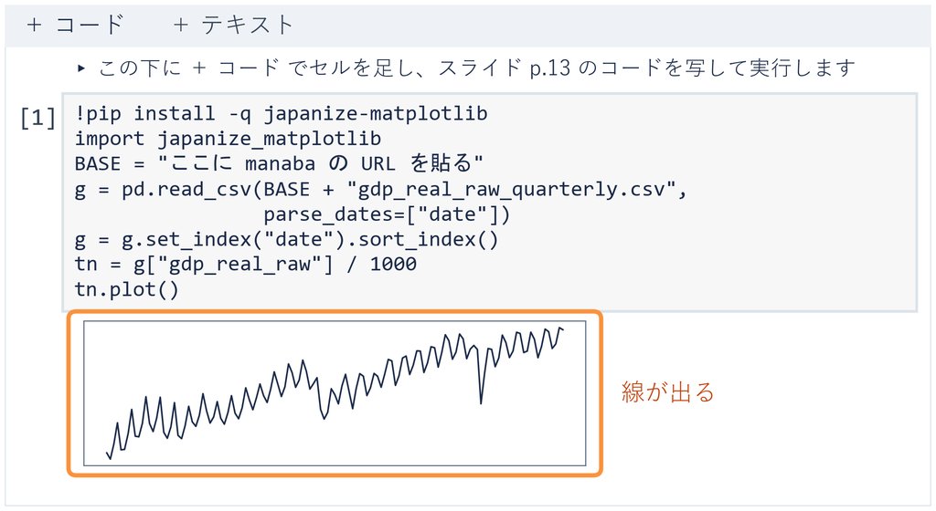

⏸ PAUSE 動画を止めて $3$ 分。線が出たら再生に戻る

## 実質 GDP 原系列の時系列プロット

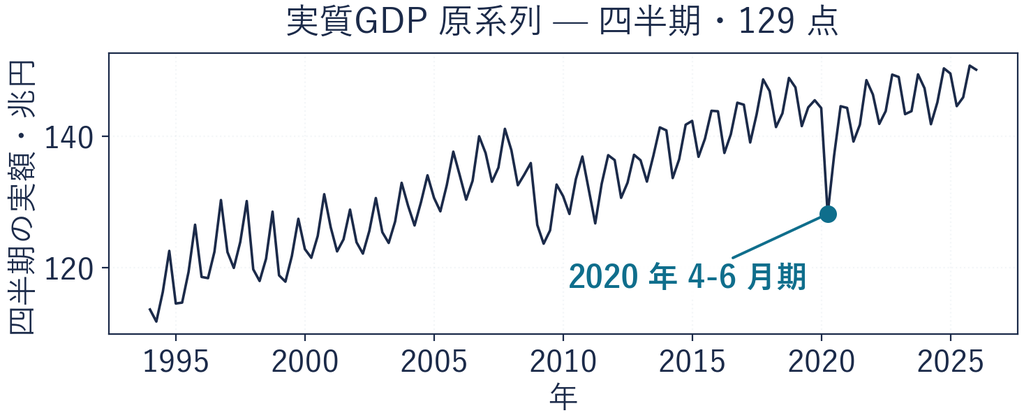

右肩上がりの流れの上に、毎年くりかえす細かい上下が乗っている

## ✋ たしかめ 細かい上下の正体

たしかめ

線に乗っている、あの細かい上下は何か

1. 予想を 1 つ選ぶ：① 測り間違い ② 景気の波 ③ 毎年くり返す何か
2. ヒント：アイス店の線では、山がどこに来ていたか
3. 選んだ理由も、少し考えてみる

⏸ PAUSE 動画を止めて $1$ 分。予想を決めたら再生に戻る

## たしかめの答えと期間の切り出し

答えは **③**。2015〜2020 年を切り出すと、  
毎年同じ時期に同じ形が戻る（2020 年は例外）

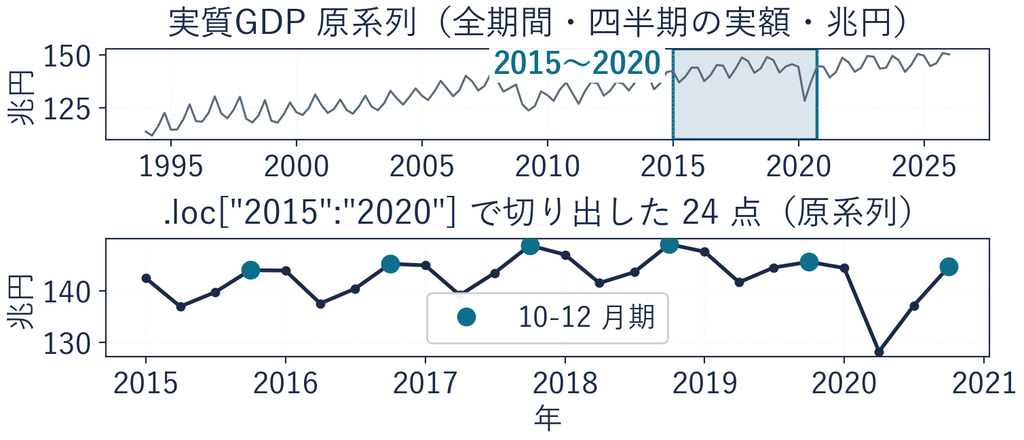

`g.loc["2015":"2020"]`：期間を切る（24 行）

## よくある失敗 文字列のままの日付列

✕ `parse_dates` を書かずに読む

実質 GDP 原系列を読むと

```
g.
index.dtype
```

は文字列  
（`object`。版によっては `str`）

`.loc["2015":"2020"]`  
は**文字として比べる**

`"2020-01-01"` > `"2020"`  
だから範囲の外 → **20 行**

○ `parse_dates=["date"]` で読む

`g.index.dtype` は `datetime64`

`.loc["2015":"2020"]`  
は**日付として比べる**

2020 年の 4 四半期も入って **24 行**

そう思ってしまう理由は、`2015-01-01` のような書き方なら、  
文字のままでも並びは合ってしまうから

## 演習 7-1 期間の変更

演習 7-1

期間を 2019〜2021 年にすると、何行になるか

```python
cut = tn.loc["2015":"2020"]
print(len(cut), cut.idxmin())
```

1. **先に考える**：ⓐ 8 行 ⓑ 12 行（2021 年が入るか）
2. **写して変える**：1 行目を `"2019":"2021"` に（1 か所）
3. **終わり**：答え欄に ⓐ か ⓑ・行数・谷の時期

※ `idxmin()`：いちばん小さい値の行の日付

⏸ PAUSE 動画を止めて $3$ 分。答えを書いたら再生に戻る

## 演習 7-1 の答え

答えは **ⓑ 12 行**。日付型の期間は、終わりの年（2021 年）まで入る

| 期間 | 行数 | いちばん深い谷 |
| --- | --- | --- |
| `"2015":"2020"` | 24 | 2020 年 4-6 月期 |
| `"2019":"2021"` | 12 | 2020 年 4-6 月期 |

3 年 × 4 ＝ 12 行。谷は 128.2 兆円。  
文字のままの日付なら 8 行（失敗例と同じ形）

## まとめ

- 時系列は、行の順番そのものに意味がある。断面データ  
  （同じ時点で、47 都道府県のように並べた表）とはそこが違う
- 作り方：**STEP 1** 日付型で読む → **2** 軸に据えて並べる → **3** 描く
- アイス店の 8 行も GDP の 129 行も、同じ 3 行で描けた
- 文字のままでも動いてしまう。だから日付型で読む
- 軸が日付なら、期間は `.loc` の 1 行で切れる

日付を軸にして並べると、線が時間の順になり、毎年くり返す上下が見えた  
残った問い：隣の時期と比べるだけでは、  
伸びか夏のせいか言えない。これを次のトピックで見る

経済データとプログラミングII

第7回 — Topic02

移動平均と季節性

ギザギザの正体は何？

## 第7回の道のり

1

日付を軸にする

実習：実行 アイス店の売上を描く

実習：写経 実質 GDP 原系列の線

演習 7-1 期間の変更

2

ならす

実習：実行 アイス店の移動平均

実習：写経 窓幅 4 と 8

演習 7-2 窓幅の変更

3

分ける

実習：写経 分解と季節調整

演習 7-3 残差の谷

4

外す・確かめる

実習：写経 1 前年比

実習：写経 2 自己相関

演習 7-4 ずらす幅の変更

いまココ — 毎年くり返す上下をならして、長い流れを取り出す

## このトピックで学ぶこと

- **いまの道具**：日付を軸にして、アイス店の売上の線は描けた
- **足りないもの**：最新の 10-12 月は 30 → 25 万円。店は不調？
- **問い**：毎年の上下をならして、長い流れが伸びているかを見たい
- **このトピック**：直近 4 期の平均を並べる**移動平均**

1 年分の窓で平均すると、毎年の上下が打ち消し合い、長い流れが残る

## ◼ 季節性

用語

**季節性**：毎年同じ時期に、同じ向きにくり返す動き

- **身近な例**：アイス店は毎年 7-9 月に売上の山、1-3 月に谷
- **言ってはいけないこと**：10-12 月の減りだけ見て「店が不調」
- **景気の波との違い**：季節性は 1 年で 1 周、景気の波は数年で 1 周

くり返すと分かっている上下は、くり返しとして扱う

## アイス店の 2 年の重ね描き

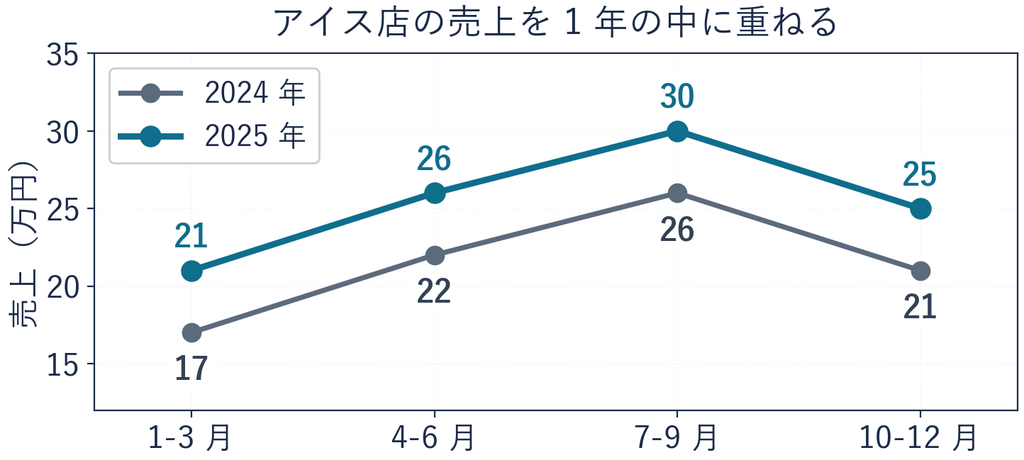

2 年とも同じ形。2025 年は、どの 3 か月も 4 万円上

## ① 最初の窓の平均

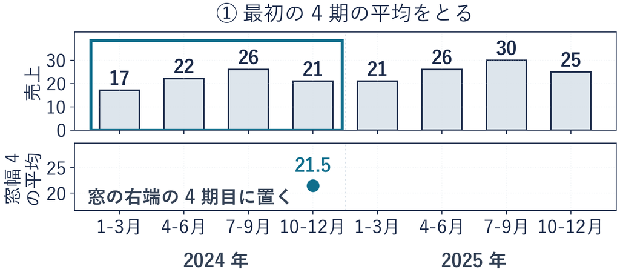

$(17+22+26+21) \div 4 = 86 \div 4 = 21.5$ を、4 期目に置く

## ② 1 つずらした窓の平均

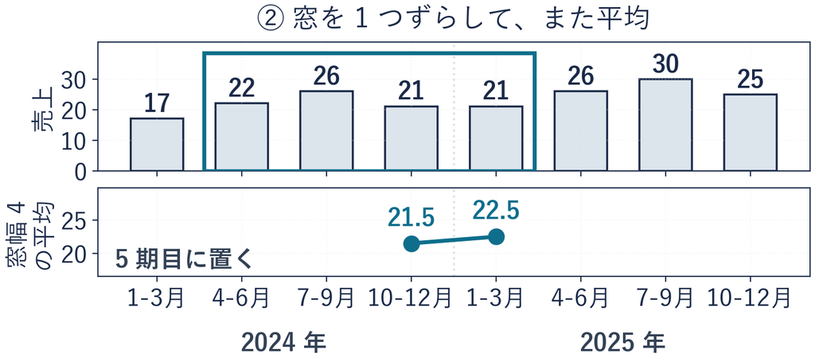

1 つずらして $(22+26+21+21) \div 4 = 90 \div 4 = 22.5$ を、5 期目に置く

## ③ 最後までずらした平均の並び

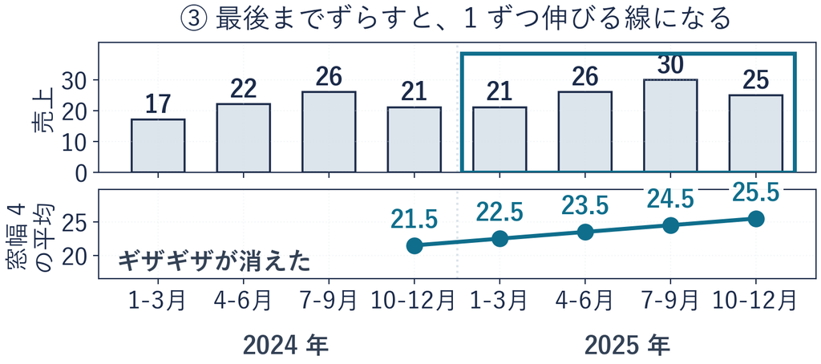

ギザギザが消えて、21.5 → 22.5 → 23.5 → 24.5 → 25.5 と 1 ずつ伸びる

## ◼ 移動平均

定義

**移動平均**：直近 $k$ 期の平均を、いまの期に置いて並べたもの

**窓幅** $k$：平均に入れる期の数

$y_t$：$t$ 期の売上（$t$ はいまの期）

- **ことばの式**：いまの期の移動平均 ＝ いまを含む直近 4 期の合計 ÷ 4
- **記号の式**：$t$ 期の移動平均 ＝ $(y_{t-3} + y_{t-2} + y_{t-1} + y_t) \div 4$
- **今回は**：4 期目 ＝ $(17+22+26+21) \div 4 = 21.5$

4 期で 1 年分。山と谷が 1 回ずつ窓に入り、打ち消し合う

## 季節の周期と窓幅

| 窓幅 | 窓の長さ | 並んだ平均（万円） | 線 |
| --- | --- | --- | --- |
| 2 | 半年 | 19.5, 24, 23.5, 21, 23.5, 28, 27.5 | 上下が残る |
| **4** | **1 年** | **21.5, 22.5, 23.5, 24.5, 25.5** | **1 ずつ伸びる** |

- **窓幅 2**：4-6・7-9 月の窓は高く、10-12・1-3 月の窓は低い
- **窓幅 4**：どの窓にも 4 つの 3 か月が 1 回ずつ入る

季節を消す窓幅は、1 年分

## 急な変化が入ったときの移動平均

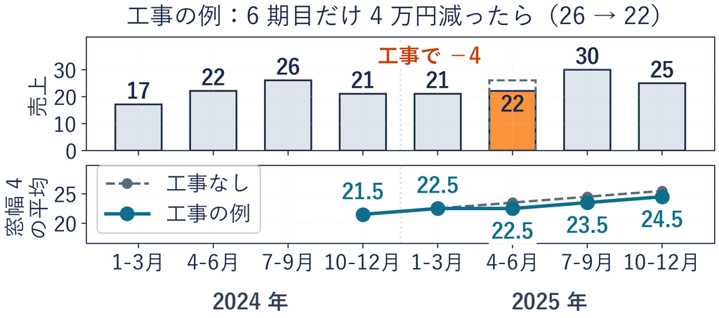

$-4$ 万円は 4 で割られ、窓 1 つあたり $-1$。伸びが 1 回止まって見えるだけ

## アイス店の移動平均のセル

```python
ma4 = ice["sales"].rolling(4).mean()
print(ma4)
```

| 行 | 部品 | 意味 |
| --- | --- | --- |
| 1 | `rolling(4).mean()` | 4 期ずつの窓を作り、 窓ごとの平均を窓の右端の期に置く |
| 2 | `print(ma4)` | 8 期分を表示する |

| 期 | 1 | 2 | 3 | 4 | 5 | 6 | 7 | 8 |
| --- | --- | --- | --- | --- | --- | --- | --- | --- |
| 出力 | NaN | NaN | NaN | 21.5 | 22.5 | 23.5 | 24.5 | 25.5 |

**写経せず、そのまま実行するセル**。`ice` は前のトピックで作った表  
`NaN`：値が無い印（最初の 3 期は窓に 4 期そろわない）

## 季節パターンの重ね描き

今度は実質 GDP で、同じ見方を。32 年分を 1 年の中に重ねる

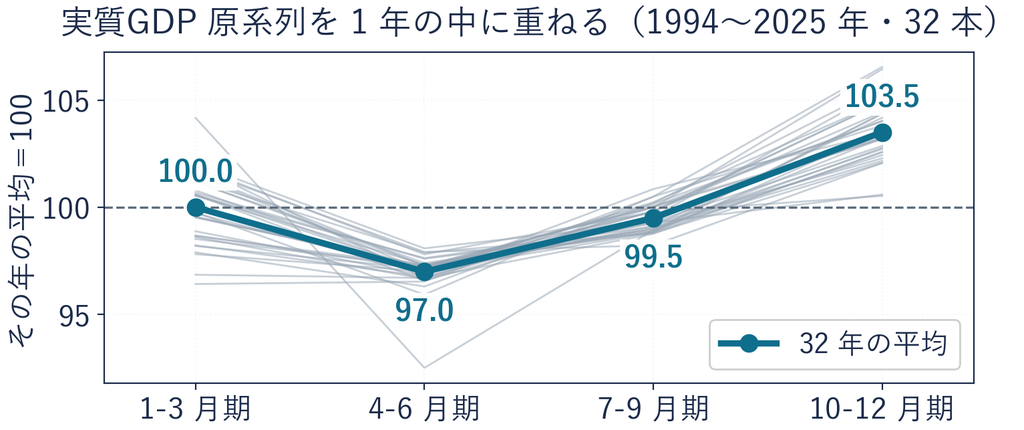

その年の平均を 100 にそろえた。10-12 月期は 32 年すべて平均より上

## ✋ たしかめ 窓幅を広げた移動平均

たしかめ

窓幅 4 を 8 に広げると、2020 年 4-6 月期の谷はどうなるか

1. 予想を 1 つ選ぶ：① 谷はそのまま残る ② 谷が浅くなる
2. ヒント：工事の例で、$-4$ 万円はどうなったか
3. 選んだ理由も、少し考えてみる

⏸ PAUSE 動画を止めて $1$ 分。予想を決めたら再生に戻る

## 写経 窓幅 4 と 8 の重ね描き

```python
y = g["gdp_real_raw"] * 4 / 1000
ma = pd.DataFrame({"原系列": y,
                   "窓幅 4": y.rolling(4).mean(),
                   "窓幅 8": y.rolling(8).mean()})
ma.plot()
```

| 行 | 部品 | 意味 |
| --- | --- | --- |
| 1 | `* 4 / 1000` | 3 か月の値を 4 倍して 1 年分に（年率換算）。1000 で割って兆円 |
| 2 | `pd.DataFrame({…})` | 3 本の線を、名前をつけて 1 つの表に並べる |
| 3-4 | `rolling(4)`・`rolling(8)` | 窓幅 4（アイス店と同じ）と窓幅 8（2 年分） |
| 5 | `ma.plot()` | 3 本を重ねて描く |

※ `g` は前のトピックの写経で読んだ表。`* 4` は年率換算で、窓幅の 4 とは別

## コードセルの写経と実行

1. **＋ コード**で空のセルを足す  
   （案内の文の下）
2. 前のページの写経、  
   5 行を上から写す
3. **▶** か **Shift + Enter** で実行  
   （Mac は Shift + return）
4. セルの下に、  
   3 本の線が出る

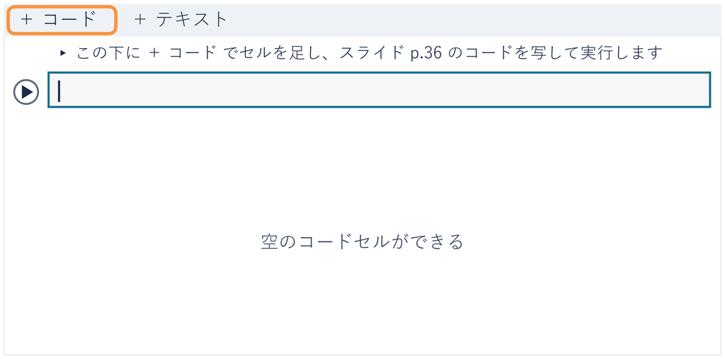

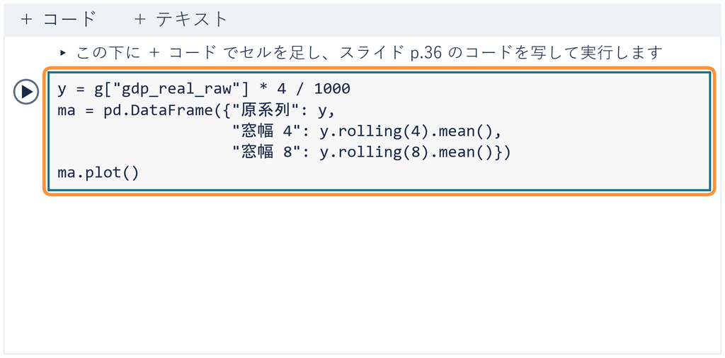

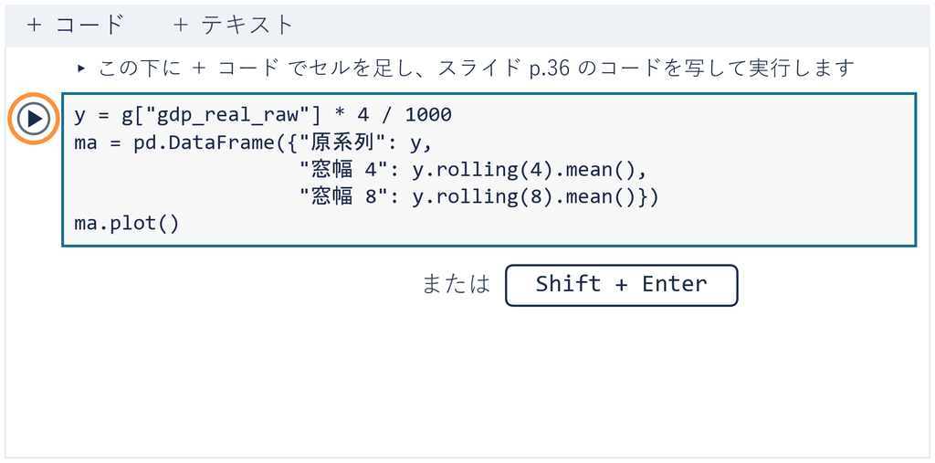

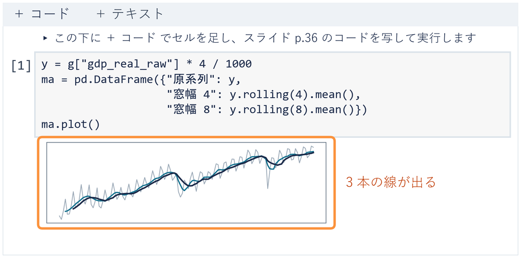

⏸ PAUSE 動画を止めて $3$ 分。3 本出たら再生に戻る

## 窓幅と谷の浅さ

[figure not shown]

たしかめの答えは **②**。工事の例と同じく、急な落ち込みが薄まる  
2020 年 4-6 月期の値は、原系列で 512.8 兆円、窓幅 4 で 562.5 兆円

## よくある失敗 窓幅と正確さの取り違え

✕ 窓幅を広げるほど正確になる

2020 年 4-6 月期の値は、  
窓幅 $8$ では $572.1$ 兆円

いちばん滑らかな線が

いちばん谷の深さから遠い

○ 窓幅は目的で決める

長い流れを見たいなら広く

急な変化を捉えたいなら狭く

ニュースの「$7$ 日移動平均」  
「$25$ 日移動平均」も同じ道具

広い窓は谷を消す代わりに、長い流れを見やすくする。  
どちらを取るかが「目的で決める」の意味

## 演習 7-2 窓幅の変更

演習 7-2

窓幅を 2 にすると、ギザギザは消えるか

```python
m = y.rolling(4).mean()
m.loc["2015":"2019"].plot(marker="o")
```

1. **先に考える**：ⓐ ギザギザが消える ⓑ ギザギザが残る
2. **写して変える**：1 行目の `rolling(4)` を `rolling(2)` に（1 か所）
3. **終わり**：線が出たら、答え欄に ⓐ か ⓑ と理由を一言

※ `marker="o"`：点を打つ。上がり下がりが数えやすい

⏸ PAUSE 動画を止めて $3$ 分。答えを書いたら再生に戻る

## 演習 7-2 の答え

答えは **ⓑ 残る**。半年の窓には、1 年分の山と谷がそろわない

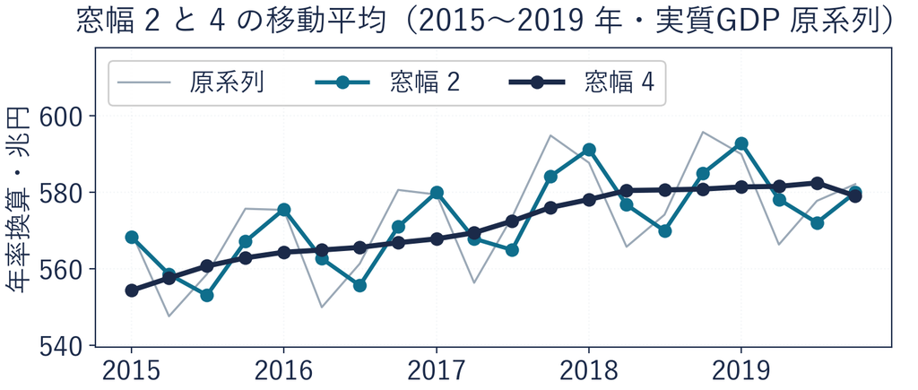

2015〜2019 年の 19 回の動きで、下がったのは窓幅 2 で 10 回、窓幅 4 で 1 回

## まとめ

- 季節性：毎年同じ時期に、同じ向きにくり返す動き
- 移動平均：直近 $k$ 期の平均を、いまの期に置いて並べる
- 窓幅 4 は 1 年分。アイス店は 21.5 から 1 ずつ伸びる線が残った
- 急な変化は薄まる。GDP の 2020 年 4-6 月期は、  
  窓幅 4 で 49.7 兆円浅く出た
- 窓幅は目的で決める。広いほど正確、ではない

1 年分の窓でならすと、季節が消えて長い流れが残った  
残った問い：消えた季節の大きさは、いくらだったのか  
これを次のトピックで見る

経済データとプログラミングII

第7回 — Topic03

成分分解と季節調整済の選び方

この線は何でできている？

## 第7回の道のり

1

日付を軸にする

実習：実行 アイス店の売上を描く

実習：写経 実質 GDP 原系列の線

演習 7-1 期間の変更

2

ならす

実習：実行 アイス店の移動平均

実習：写経 窓幅 4 と 8

演習 7-2 窓幅の変更

3

分ける

実習：写経 分解と季節調整

演習 7-3 残差の谷

4

外す・確かめる

実習：写経 1 前年比

実習：写経 2 自己相関

演習 7-4 ずらす幅の変更

いまココ — 1 本の線を 3 つに分けて、季節の大きさを測る

## このトピックで学ぶこと

- **いまの道具**：移動平均で、長い流れ（21.5 → 25.5）は見えた
- **足りないもの**：7-9 月 30 → 10-12 月 25 万円。  
  5 万円減のうち、季節の分は？
- **問い**：ならすと季節は消えるだけ。  
  消えた季節を取り出して測りたい
- **このトピック**：線を 3 つの部分に分ける**成分分解**

長い流れ・毎年の形・残りに分けて、どれがいくら動いたかを言う

## ◼ 時系列の成分分解

定義

**成分分解**：1 本の線を、3 つの部分の足し算に分けること
$$\text{系列} = \text{トレンド} + \text{季節} + \text{残差}$$

- **トレンド**：何年もかけて伸びたり縮んだりする、長い流れ
- **季節**：毎年同じ時期にくり返す形（3 か月ごとに 4 つの数）
- **残差**：元の値から、トレンドと季節を引いて残った分
- **今回は**：アイス店の 1 期目は $17 = 20 + (-3) + 0$

足し算で分けるので、3 つを足すと元の値に戻る

## 足し算で作るアイス店の売上

[figure not shown]

20 から 1 ずつ伸びる流れに毎年同じ季節を足した数が、表の売上

## デモ：分けてみる実験室

数の話

系列 ＝ トレンド ＋ 季節 ＋ 残差 — 足して作れるもの  
は、分けて取り出せる

- **何を見るか**：作った線と GDP の原系列を、同じ道具で分ける
- **図の意味**：上に 1 本の線、下に 3 段、右に読み出し
- **操作**：タブ 3 つ、スライダ 3 本で形を変える

ミッション タブ ①② だけで季節の**振幅**  
（山と谷の大きさ）を $0$ にする

※ 次のスライドへ進むときは、デモの枠の外を一度クリックしてから ← → キーを押す

[interactive chart not shown]

## ◼ 季節調整の手順

手順

STEP 1窓の真ん中で移動平均をとり、**トレンド**にする

STEP 2元の値からトレンドを引く

STEP 3同じ 3 か月どうしで平均して**季節**。残りが**残差**

STEP 4元の値から季節を引く（この処理が**季節調整**）

次のページから、アイス店の 8 期で STEP 1 から順に

## STEP 1 窓の真ん中のトレンド

移動平均は窓の右端に置いた。トレンドは窓の真ん中に置く

[figure not shown]

$(21.5 + 22.5) \div 2 = 22$ を 3 期目に。同じように 23・24・25

## STEP 2・3 季節と残差

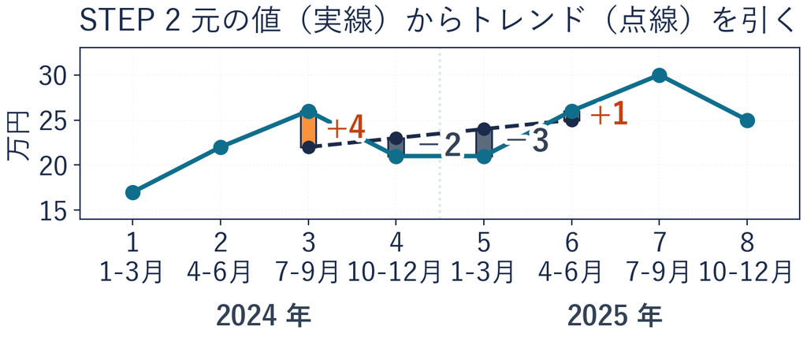

| 3 か月 | 1-3 月 | 4-6 月 | 7-9 月 | 10-12 月 |
| --- | --- | --- | --- | --- |
| 元 − トレンド | −3 | +1 | +4 | −2 |
| **季節**（STEP 3） | **−3** | **+1** | **+4** | **−2** |

8 期では同じ 3 か月が 1 つずつ。平均はその数のまま、残差は 0

## STEP 4 季節を引いた線

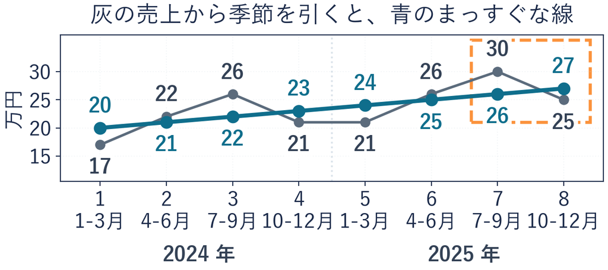

**季節調整**：元の値から季節を引いて、毎年の形を取り除くこと

**季節調整済み系列**：季節を引いたあとの線

店は伸びている。10-12 月の −5 万円は、季節の分 −6 と伸び +1

## 写経 加法分解と季節調整

今度は実質 GDP で、同じ STEP を

```python
from statsmodels.tsa.seasonal import seasonal_decompose
d = seasonal_decompose(y, period=4)
d.plot()
mine = y - d.seasonal
```

| 行 | 部品 | 意味 |
| --- | --- | --- |
| 1 | `seasonal_decompose` | 分ける道具を呼ぶ（前に使った statsmodels の別の 1 関数） |
| 2 | `period=4` | 4 期で 1 周として STEP 1〜3 を行う。結果 `d` に 3 つの部分が入る |
| 3 | `d.plot()` | 元の線・トレンド・季節・残差の 4 段を描く |
| 4 | `y - d.seasonal` | **STEP 4** 季節を引く。自分で作った季節調整済み系列 |

※ `y` は前のトピックの写経で作った、年率換算の原系列（兆円）

## コードセルの写経と実行

1. **＋ コード**で空のセルを足す  
   （案内の文の下）
2. 前のページの写経、  
   4 行を上から写す
3. **▶** か **Shift + Enter** で実行  
   （Mac は Shift + return）
4. セルの下に、  
   4 段の図が出る

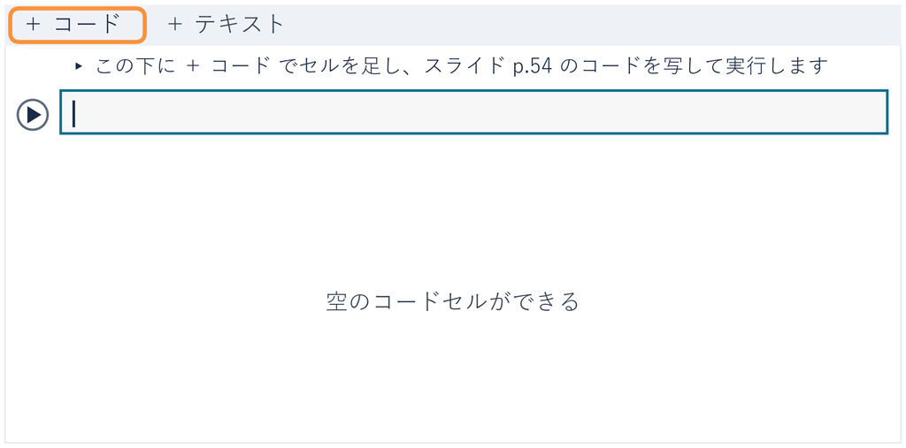

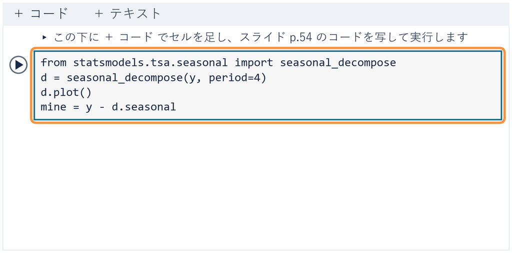

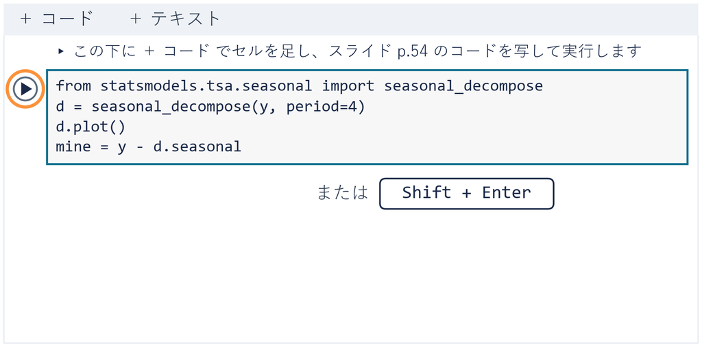

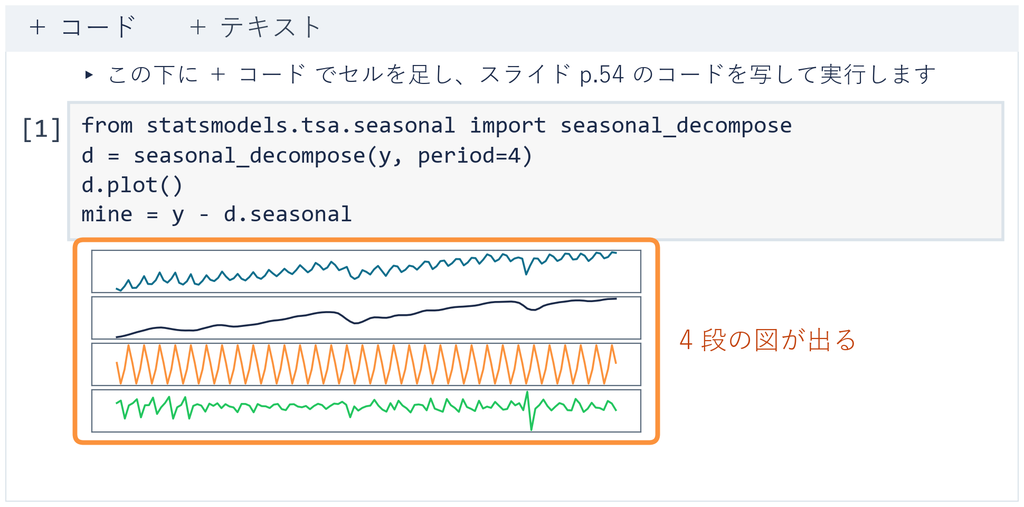

⏸ PAUSE 動画を止めて $3$ 分。4 段の図が出たら再生に戻る

## 加法分解の 4 段の図

[figure not shown]

アイス店と同じ順に読む。残差の段に、深い谷が 1 つある

## 演習 7-3 残差の谷

演習 7-3

残差がいちばん沈んだのは、いつか

```python
r = d.resid
print(r.min())
```

1. **先に考える**：ⓐ 2009 年 1-3 月期 ⓑ 2020 年 4-6 月期
2. **写して変える**：2 行目の `min()` を `idxmin()` に（1 か所）
3. **終わり**：日付が出たら、答え欄に ⓐ か ⓑ と理由を一言

※ 写したまま実行すると、いちばん沈んだ深さ（兆円）が出る。`idxmin()` はその日付

⏸ PAUSE 動画を止めて $3$ 分。答えを書いたら再生に戻る

## 演習 7-3 の答え

答えは **ⓑ 2020 年 4-6 月期**。残差は年率換算で $-26.3$ 兆円

| セル | 出力 | 読み方 |
| --- | --- | --- |
| `print(r.min())` | `-26.2654…` | いちばん沈んだ深さ （兆円） |
| `print(r.idxmin())` | `2020-04-01 00:00:00` | その日付 （2020 年 4-6 月期） |

残差は、トレンドでも季節でも説明できない動き。  
ⓐ の 2009 年 1-3 月期は $-12.0$ 兆円

## ✋ たしかめ 自作の季節調整と公表値

たしかめ

自分で引いた線は、国の公表値にどこまで近いか

内閣府は、季節を調整した系列（**公表の季節調整済**）  
も出している。比べる相手はそれ

1. 予想を 1 つ選ぶ：① ほぼ同じ ② 半分は合う ③ 違う線
2. 選んだ理由も、少し考えてみる

⏸ PAUSE 動画を止めて $1$ 分。予想を決めたら再生に戻る

## ★ 自作と公表値の季節調整の比較

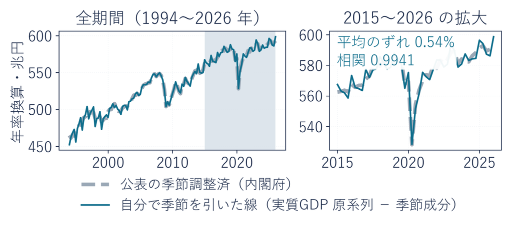

**相関**：2 本の線が同じ向きに動く強さ（$-1$ 〜 $+1$）  
たしかめの答えは **①**。相関 $0.9941$・平均のずれ $0.54$%  
季節を引かない原系列のままなら、相関 $0.951$・ずれ $1.94$%

## 原系列の四半期別の伸び率

季節を引かずに原系列のまま、前の期から何 % 伸びたかを並べる

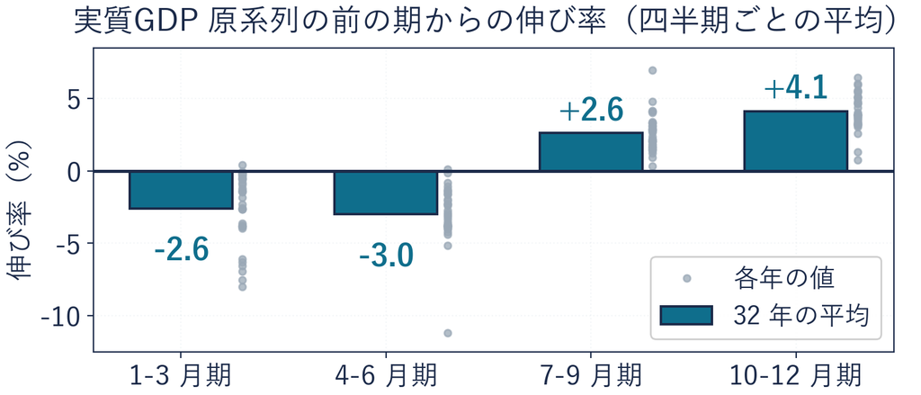

1-3 月期は 32 年のうち 31 年でマイナス。平均 $-2.6$%

## よくある失敗 季節の落ち込みの読み違え

✕ 原系列の伸び率だけで読む

1-3 月期に $2.6$% 落ちた

だから不況だ

（原系列の 1-3 月期は 32 年の  
平均で $-2.6$%）

○ 季節を引いた系列で読む

季節を引いた系列なら

1-3 月期の伸び率は平均 $+0.15$%

落ちているのは季節の分

そう読みたくなる理由は、  
数字が確かに落ちていて、ニュースもそう読むから

## 公表の季節調整済み系列

法則

**多くの公表統計は、原系列と季節調整済み系列を両方出す**  
**作るのではなく、目的に合う系列を選ぶのが第一選択**

- **自分で分けると**：自作と**公表の季節調整済**のずれは平均 $0.54$%
- **公表値**：X-13ARIMA-SEATS という専用の季節調整法で作る
- **取り切れたか**：季節が残っていないかの確かめは、次のトピックで
- **選び方**：前の期と比べて今の動きを読むなら季節調整済み。  
  毎年の形を調べるなら原系列

e-Stat（政府統計の総合窓口）や内閣府の統計表で選ぶ

## まとめ

- 成分分解：系列 ＝ トレンド ＋ 季節 ＋ 残差。足すと元に戻る
- 手順：**STEP 1** トレンド → **2** 引く → **3** 季節 → **4** 季節を引く
- アイス店の 10-12 月の −5 万円は、季節 −6 と伸び +1
- GDP の季節の幅は平均水準の 6.1%。残差の谷は 2020 年 4-6 月期
- 自作は公表値まで 0.54%。それでも目的に合う公表系列を選ぶ

3 つに分けると、季節の大きさと残差の事件が数で言えた  
残った問い：分けずに季節を外す道はないか。取り切れたかは、どう測るか  
これを次のトピックで見る

経済データとプログラミングII

第7回 — Topic04

変化率とラグ・自己相関

前年比は何を消している？

## 第7回の道のり

1

日付を軸にする

実習：実行 アイス店の売上を描く

実習：写経 実質 GDP 原系列の線

演習 7-1 期間の変更

2

ならす

実習：実行 アイス店の移動平均

実習：写経 窓幅 4 と 8

演習 7-2 窓幅の変更

3

分ける

実習：写経 分解と季節調整

演習 7-3 残差の谷

4

外す・確かめる

実習：写経 1 前年比

実習：写経 2 自己相関

演習 7-4 ずらす幅の変更

いまココ — 分けずに季節を弱める道と、取り切れたかの確かめ

## このトピックで学ぶこと

- **いまの道具**：分解すれば、季節を引いた線が作れる
- **足りないもの**：でも STEP が 4 つ要る。ニュースは  
  「前年同期比で何 % 増えた」と割合 1 つで言う
- **問い**：分けずに季節を弱めて、伸びを言えないか。  
  取り切れたかも測りたい
- **このトピック**：同じ季節どうしで比べる**前年比**と、  
  季節の残りを測る**自己相関**

前年比は、同じ季節どうしで比べて、分けずに季節を弱める道

## ラグ変数

**$y_t$**：$t$ 期目の売上。$y_{t-1}$ は 1 期前、$y_{t-4}$ は 4 期前の売上

**ラグ変数**：列を下にずらして、前の期の値を横に並べた列

[figure not shown]

ずらす幅を**ラグ**と呼ぶ。4 つずらすと、1 年前の同じ 3 か月が横に並ぶ  
前の回の 1〜12 か月前の先行の列も、`shift` で作ったラグ変数

## 差分と変化率

**差分**：今の値から前の値を引いた数（何万円変わったか）

**変化率**：差分を前の値で割って 100 倍（何 % 変わったか）

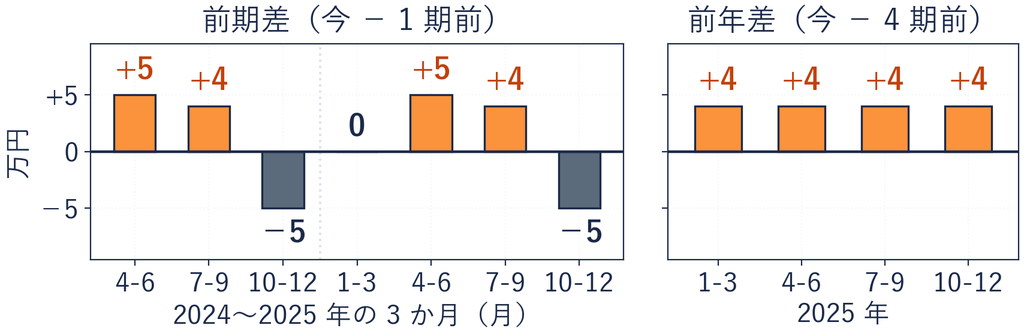

1 期前との差は季節で上下。4 期前との差は 4 万円の伸びだけ

## ◼ 前期比と前年比

定義

**前期比**：1 期前と比べた変化率（前のトピックの伸び率）

**前年比**：1 年前と比べた変化率（ニュースの「前年同期比」）

$$\text{前年比} = \frac{y_t - y_{t-4}}{y_{t-4}} \times 100$$

- **ことばの式**：（今の売上 − 1 年前の売上）÷ 1 年前の売上 × 100
- **なぜ 4 期前**：同じ 3 か月どうし。夏は去年の夏と、冬は去年の冬と比べる
- **なぜ割る**：大きさの違う店や国も、同じ % で比べるため
- **今回は**：2025 年 1-3 月は $(21 - 17) \div 17 \times 100 \approx 23.5$%

## アイス店の前年比

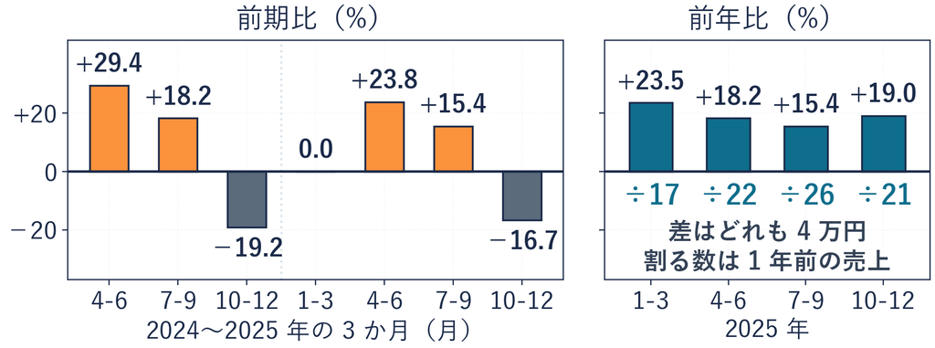

季節は弱まる。でも割る数に季節が入り、15.4〜23.5% とずれが残る

## 写経 前年比の計算と折れ線

今度は実質 GDP で、同じ前年比を

```python
yoy = y.pct_change(4) * 100
yoy.plot()
```

| 行 | 部品 | 意味 |
| --- | --- | --- |
| 1 | `pct_change(4)` | 4 期前と比べた変化率。引いて割るのを 1 回で |
| 1 | `* 100` | % にする |
| 2 | `yoy.plot()` | 前年比を折れ線に描く |

※ `y` は前のトピックまでの写経で作った原系列（年率換算・兆円）。  
先頭の 4 期は比べる相手が無く空（NaN）

## コードセルの写経と実行

1. **＋ コード**で空のセルを足す  
   （案内の文の下）
2. 前のページの写経、  
   2 行を上から写す
3. **▶** か **Shift + Enter** で実行  
   （Mac は Shift + return）
4. セルの下に、  
   前年比の線が出る

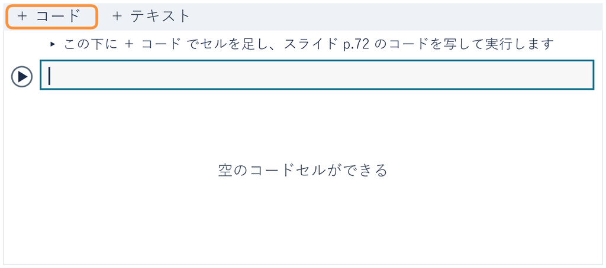

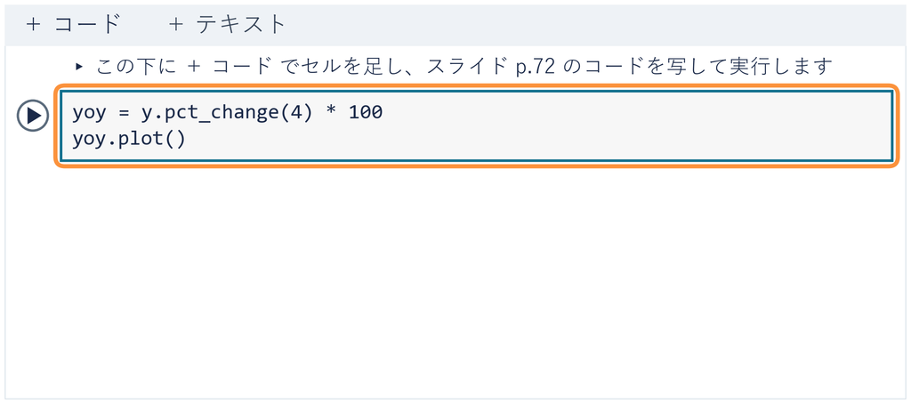

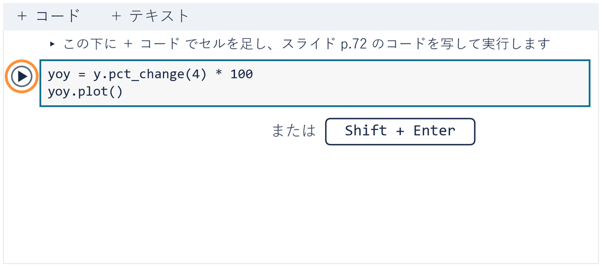

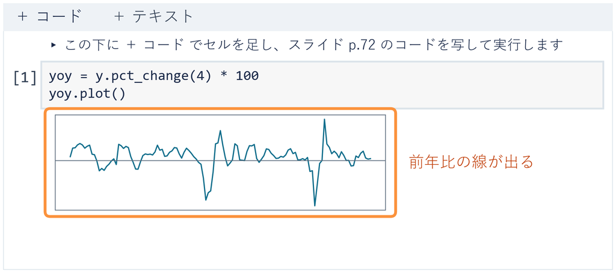

⏸ PAUSE 動画を止めて $2$ 分。前年比の線が出たら再生に戻る